# Finding interesting clusters using snorkel

With unsupervised learning methods it can be challenging to automatically figure out which clusters are useful/interesting. By using collections of weak labels, we can automatically identify potentially interesting (or less interesting) clusters. The overall strategy is as follows:

1. Vectorize the data
2. Embed the data into a lower dimensional space using [UMAP](https://umap-learn.readthedocs.io/en/latest/)
3. Run density based clustering using [HDBSCAN](https://hdbscan.readthedocs.io/en/latest/index.html)
4. Write labeling functions using [snorkel](https://www.snorkel.org/) to get collections of weak labels
5. Identify clusters that contain many points (e.g. >90%) with a given label

Optionally we can go a step further. Snorkel can train predict an overall label for a point (given the set of weak labels) using [weak supervision](https://www.snorkel.org/blog/weak-supervision) methods. We can use this to find potentially interesting clusters.

1. Use snorkel to generate an overall label for each data point using weak supervision
2. Train a supervised learning model to predict this overall label (hoping it generalizes better). It can also use a different feature set than the snorkel model.
3. Predict a label for every point in the dataset.
4. Identify clusters that have a high proportion of a given label. Or if you have a lot of confidence in your model, use it to prune your clusters.

This notebook is an extension of the great [snorkel spam tutorial](https://www.snorkel.org/use-cases/01-spam-tutorial). It uses a youtube comment dataset which have been labeled as SPAM or HAM. We won't actually use the labels to train a model, just verify that we're on the right track.

```python
import json
import pandas as pd
import numpy as np
import umap
import umap.plot

import scipy.sparse

import hdbscan

from sklearn.feature_extraction.text import CountVectorizer

import matplotlib.pyplot as plt

from warnings import warn
import numba

umap.plot.output_notebook()
```

```python
# Download the spaCy english model
# You should only need to run this once but after running it restart your jupyter kernel
# ! python -m spacy download en_core_web_sm
```

### Load in the spam dataset

```python
from utils import load_spam_dataset

df_train, df_test = load_spam_dataset()

# We pull out the label vectors for ease of use later
Y_test = df_test.label.values
```

### Vectorize the text to use with UMAP

Here we are just using CountVectorizer from sklearn but there are a large number of different vectorizers in [this repository](https://github.com/TutteInstitute/vectorizers)

```python
vectorizer = CountVectorizer(min_df=1, stop_words='english')
word_doc_matrix = vectorizer.fit_transform(df_train.text)
```

```python
word_doc_matrix
```

```
<1586x3699 sparse matrix of type '<class 'numpy.int64'>'
	with 12448 stored elements in Compressed Sparse Row format>
```

### Use UMAP to embed the vectorized text into a lower dimensional space

```python
%%time
embedding_model = umap.UMAP(n_components=2, metric='hellinger')
embedding = embedding_model.fit_transform(word_doc_matrix)
```

```
OMP: Info #271: omp_set_nested routine deprecated, please use omp_set_max_active_levels instead.
Disconnection_distance = 1 has removed 2033938 edges.
It has only fully disconnected 26 vertices.
Use umap.utils.disconnected_vertices() to identify them.
  warn(
```

```
CPU times: user 18.3 s, sys: 1.57 s, total: 19.9 s
Wall time: 7.71 s
```

We have some disconnected components so we can remove them. If we leave them in HDBSCAN will throw errors

```python
is_disconnected = umap.utils.disconnected_vertices(embedding_model)
is_connected = [not x for x in is_disconnected]
connected_embedding = embedding[is_connected]
```

### Cluster the embedding using HDBSCAN

```python
clusterer = hdbscan.HDBSCAN(metric='euclidean', min_cluster_size=5)
cluster_labels = list(clusterer.fit_predict(connected_embedding))
```

Add in a cluster label of -2 for disconnected points so that we can easily ignore them later

```python
for idx, val in enumerate(is_disconnected):
    if val:
        cluster_labels.insert(idx, -2)
```

### Show some data when hovering over a point

```python
comment_text = df_train['text'].reset_index(drop=True)
hover_df = pd.DataFrame({'text': comment_text})
hover_df['cluster'] = cluster_labels
hover_df.reset_index(drop=True, inplace=True)
```

### Plot the embedding

```python
f = umap.plot.interactive(embedding_model, labels=hover_df['cluster'], hover_data=hover_df, subset_points=is_connected)
umap.plot.show(f)
```

[interactive chart not shown]

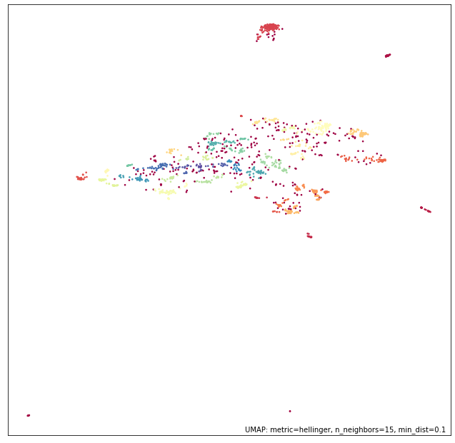

```python
f = umap.plot.points(embedding_model, labels=hover_df['cluster'], subset_points=is_connected, show_legend=False)
umap.plot.show(f)
```

### Using snorkel

All of these labeling functions are taken from the [snorkel spam tutorial](https://www.snorkel.org/use-cases/01-spam-tutorial) so I won't go into too much detail with them. There are a wide variety of labeling functions you can create, including fairly sophisticated ones.

```python
import re
from collections import Counter

from snorkel.labeling import labeling_function, LabelingFunction
from snorkel.preprocess import preprocessor
from textblob import TextBlob
from snorkel.preprocess.nlp import SpacyPreprocessor
from snorkel.labeling.lf.nlp import nlp_labeling_function
from snorkel.labeling import PandasLFApplier
```

```python
# For clarity, we define constants to represent the class labels for spam, ham, and abstaining.
ABSTAIN = -1
HAM = 0
SPAM = 1
```

Generic labeling functions

```python
@labeling_function()
def check(x):
    return SPAM if "check" in x.text.lower() else ABSTAIN


@labeling_function()
def check_out(x):
    return SPAM if "check out" in x.text.lower() else ABSTAIN
```

Using preprocessors and external models

```python
@preprocessor(memoize=True)
def textblob_sentiment(x):
    scores = TextBlob(x.text)
    x.polarity = scores.sentiment.polarity
    x.subjectivity = scores.sentiment.subjectivity
    return x

@labeling_function(pre=[textblob_sentiment])
def textblob_polarity(x):
    return HAM if x.polarity > 0.9 else ABSTAIN

@labeling_function(pre=[textblob_sentiment])
def textblob_subjectivity(x):
    return HAM if x.subjectivity >= 0.5 else ABSTAIN
```

Keyword based labeling

```python
def keyword_lookup(x, keywords, label):
    if any(word in x.text.lower() for word in keywords):
        return label
    return ABSTAIN


def make_keyword_lf(keywords, label=SPAM):
    return LabelingFunction(
        name=f"keyword_{keywords[0]}",
        f=keyword_lookup,
        resources=dict(keywords=keywords, label=label),
    )


"""Spam comments talk about 'my channel', 'my video', etc."""
keyword_my = make_keyword_lf(keywords=["my"])

"""Spam comments ask users to subscribe to their channels."""
keyword_subscribe = make_keyword_lf(keywords=["subscribe"])

"""Spam comments post links to other channels."""
keyword_link = make_keyword_lf(keywords=["http"])

"""Spam comments make requests rather than commenting."""
keyword_please = make_keyword_lf(keywords=["please", "plz"])

"""Ham comments actually talk about the video's content."""
keyword_song = make_keyword_lf(keywords=["song"], label=HAM)
```

Using regular expressions for labeling

```python
@labeling_function()
def regex_check_out(x):
    return SPAM if re.search(r"check.*out", x.text, flags=re.I) else ABSTAIN
```

Heuristic labeling functions

```python
@labeling_function()
def short_comment(x):
    """Ham comments are often short, such as 'cool video!'"""
    return HAM if len(x.text.split()) < 5 else ABSTAIN
```

Complex preprocessors

```python
# The SpacyPreprocessor parses the text in text_field and
# stores the new enriched representation in doc_field
spacy = SpacyPreprocessor(text_field="text", doc_field="doc", memoize=True)

@labeling_function(pre=[spacy])
def has_person(x):
    """Ham comments mention specific people and are short."""
    if len(x.doc) < 20 and any([ent.label_ == "PERSON" for ent in x.doc.ents]):
        return HAM
    else:
        return ABSTAIN
```

```python
@nlp_labeling_function()
def has_person_nlp(x):
    """Ham comments mention specific people and are short."""
    if len(x.doc) < 20 and any([ent.label_ == "PERSON" for ent in x.doc.ents]):
        return HAM
    else:
        return ABSTAIN
```

### Apply the labeling functions

```python
lfs = [
    keyword_my,
    keyword_subscribe,
    keyword_link,
    keyword_please,
    keyword_song,
    regex_check_out,
    short_comment,
    has_person_nlp,
    textblob_polarity,
    textblob_subjectivity,
]
```

```python
applier = PandasLFApplier(lfs=lfs)
L_train = applier.apply(df=df_train)
L_test = applier.apply(df=df_test)

label_names = applier._lf_names
```

We're going to visualize the embedding later. It is useful to see the counts for each of the labels on each point. E.g. this comment was labeled ABSTAIN 7 times, SPAM 2 times, and HAM 1 time.

```python
label_mapping = {-1: 'ABSTAIN', 0: 'HAM', 1: 'SPAM'}

labels = pd.DataFrame(L_train, columns=applier._lf_names)
labels = labels.applymap(lambda x: label_mapping[x])

row_counts = labels.apply(lambda row: Counter(row), axis=1)
label_df_hover = pd.DataFrame.from_dict(list(row_counts)).fillna(0.0)
label_df_hover
```

|  | ABSTAIN | SPAM | HAM |
| --- | --- | --- | --- |
| 0 | 8 | 1.0 | 1.0 |
| 1 | 7 | 2.0 | 1.0 |
| 2 | 10 | 0.0 | 0.0 |
| 3 | 10 | 0.0 | 0.0 |
| 4 | 10 | 0.0 | 0.0 |
| ... | ... | ... | ... |
| 1581 | 8 | 2.0 | 0.0 |
| 1582 | 9 | 0.0 | 1.0 |
| 1583 | 6 | 3.0 | 1.0 |
| 1584 | 7 | 2.0 | 1.0 |
| 1585 | 7 | 3.0 | 0.0 |

1586 rows × 3 columns

```python
label_df_hover['text'] = df_train['text'].reset_index(drop=True)
label_df_hover['cluster'] = cluster_labels
```

```python
f = umap.plot.interactive(embedding_model, labels=label_df_hover['cluster'], hover_data=label_df_hover)
umap.plot.show(f)
```

[interactive chart not shown]

### Find clusters with a high proportion of a given label

Here we can look for clusters that have lots of points with a given label. We can look on a per labeling function basis as well, not just overall label.

```python
def calculate_label_frequencies(df, label_names):
    hits_df = pd.DataFrame()
    grouped = df.groupby('cluster')

    for cluster in grouped.groups:
        g_df = grouped.get_group(cluster)
        # Calcuate the frequency of each label within the cluster
        frequencies = g_df[label_names].apply(pd.value_counts, normalize=True).fillna(0.0)

        frequencies_df = frequencies.stack().rename_axis(['label', 'analytic']).to_frame(name='frequency').reset_index()
        frequencies_df.insert(0, 'cluster', cluster)

        hits_df = pd.concat([hits_df, frequencies_df])
    return hits_df
```

```python
cluster_df = labels
cluster_df.insert(0, 'cluster', cluster_labels)
freqs = calculate_label_frequencies(cluster_df, label_names)
```

```python
freqs
```

|  | cluster | label | analytic | frequency |
| --- | --- | --- | --- | --- |
| 0 | -2 | ABSTAIN | keyword_my | 0.961538 |
| 1 | -2 | ABSTAIN | keyword_subscribe | 1.000000 |
| 2 | -2 | ABSTAIN | keyword_http | 1.000000 |
| 3 | -2 | ABSTAIN | keyword_please | 1.000000 |
| 4 | -2 | ABSTAIN | keyword_song | 1.000000 |
| ... | ... | ... | ... | ... |
| 25 | 70 | SPAM | regex_check_out | 0.000000 |
| 26 | 70 | SPAM | short_comment | 0.000000 |
| 27 | 70 | SPAM | has_person_nlp | 0.000000 |
| 28 | 70 | SPAM | textblob_polarity | 0.000000 |
| 29 | 70 | SPAM | textblob_subjectivity | 0.000000 |

2060 rows × 4 columns

Let's define thresholds for what it means to be "a large proportion of the points". We can define it per analytic/labeling function with a sensible default value

```python
def apply_thresholds(row, thresholds):
    if row['frequency'] >= thresholds[row['analytic']]:
        return True
    else:
        return False
```

```python
default_threshold = 0.9
thresholds = {k: default_threshold for k in label_names}
labels_of_interest = ['SPAM']
```

```python
above_threshold = freqs[freqs.apply(apply_thresholds, axis=1, thresholds=thresholds)]
above_threshold
```

|  | cluster | label | analytic | frequency |
| --- | --- | --- | --- | --- |
| 0 | -2 | ABSTAIN | keyword_my | 0.961538 |
| 1 | -2 | ABSTAIN | keyword_subscribe | 1.000000 |
| 2 | -2 | ABSTAIN | keyword_http | 1.000000 |
| 3 | -2 | ABSTAIN | keyword_please | 1.000000 |
| 4 | -2 | ABSTAIN | keyword_song | 1.000000 |
| ... | ... | ... | ... | ... |
| 2 | 70 | ABSTAIN | keyword_http | 1.000000 |
| 3 | 70 | ABSTAIN | keyword_please | 0.937500 |
| 5 | 70 | ABSTAIN | regex_check_out | 1.000000 |
| 7 | 70 | ABSTAIN | has_person_nlp | 1.000000 |
| 8 | 70 | ABSTAIN | textblob_polarity | 1.000000 |

485 rows × 4 columns

Lets look for clusters that have a lot of comments labeled SPAM

```python
spam_hits = above_threshold[above_threshold['label']=='SPAM']
spam_hits
```

|  | cluster | label | analytic | frequency |
| --- | --- | --- | --- | --- |
| 25 | 1 | SPAM | regex_check_out | 1.000000 |
| 25 | 4 | SPAM | regex_check_out | 0.954545 |
| 22 | 5 | SPAM | keyword_http | 0.900000 |
| 25 | 7 | SPAM | regex_check_out | 0.915966 |
| 21 | 12 | SPAM | keyword_subscribe | 0.977778 |
| 22 | 13 | SPAM | keyword_http | 0.909091 |
| 22 | 15 | SPAM | keyword_http | 1.000000 |
| 22 | 16 | SPAM | keyword_http | 1.000000 |
| 22 | 17 | SPAM | keyword_http | 1.000000 |
| 22 | 18 | SPAM | keyword_http | 0.954545 |
| 22 | 21 | SPAM | keyword_http | 1.000000 |
| 22 | 22 | SPAM | keyword_http | 1.000000 |
| 22 | 23 | SPAM | keyword_http | 1.000000 |
| 21 | 24 | SPAM | keyword_subscribe | 1.000000 |
| 25 | 39 | SPAM | regex_check_out | 1.000000 |

```python
clusters_with_hits = pd.unique(spam_hits['cluster'])
```

```python
clusters_with_hits
```

```
array([ 1,  4,  5,  7, 12, 13, 15, 16, 17, 18, 21, 22, 23, 24, 39])
```

### Lets try to combine labels and train a classifier

```python
from snorkel.labeling.model import MajorityLabelVoter
from snorkel.labeling.model import LabelModel
from snorkel.labeling import filter_unlabeled_dataframe
from snorkel.utils import probs_to_preds

from sklearn.linear_model import LogisticRegression
```

```python
majority_model = MajorityLabelVoter()
preds_train = majority_model.predict(L=L_train)
```

```python
label_model = LabelModel(cardinality=2, verbose=True)
label_model.fit(L_train=L_train, n_epochs=500, log_freq=100, seed=123)
```

```python
probs_train = label_model.predict_proba(L=L_train)
```

```python
df_train_filtered, probs_train_filtered = filter_unlabeled_dataframe(
    X=df_train, y=probs_train, L=L_train
)
```

```python
vectorizer = CountVectorizer(ngram_range=(1, 5))
X_train = vectorizer.fit_transform(df_train_filtered.text.tolist())
X_test = vectorizer.transform(df_test.text.tolist())
```

```python
preds_train_filtered = probs_to_preds(probs=probs_train_filtered)
```

```python
sklearn_model = LogisticRegression(C=1e3, solver="liblinear")
sklearn_model.fit(X=X_train, y=preds_train_filtered)
```

```
LogisticRegression(C=1000.0, solver='liblinear')
```

```python
print(f"Test Accuracy: {sklearn_model.score(X=X_test, y=Y_test) * 100:.1f}%")
```

```
Test Accuracy: 93.6%
```

### Plot the embedding while showing the predicted class

```python
# We need to use the same vocabulary that the model was trained on
cv = CountVectorizer(ngram_range=(1, 5), vocabulary=vectorizer.vocabulary_)
X_train_all = cv.fit_transform(df_train.text.tolist())
```

```python
pred_probs = sklearn_model.predict_proba(X_train_all)
```

```python
def get_labels_with_confidence(predictions, class_labels, threshold=0.8):
    predicted_labels = []
    for probs in predictions:

        max_idx = np.argmax(probs)
        probability = probs[max_idx]
        if probability >= threshold:
            predicted_labels.append(class_labels[max_idx])
        else:
            predicted_labels.append('ABSTAIN')

    return predicted_labels
```

```python
class_labels = ['HAM', 'SPAM']
```

```python
comment_text = df_train['text'].reset_index(drop=True)
hover_data = pd.DataFrame({'text': comment_text})
hover_data['cluster'] = cluster_labels
hover_data['predicted_label'] = get_labels_with_confidence(pred_probs, class_labels, threshold=0.8)
hover_data.reset_index(drop=True, inplace=True)
```

```python
hover_data
```

|  | text | cluster | predicted_label |
| --- | --- | --- | --- |
| 0 | pls http://www10.vakinha.com.br/VaquinhaE.aspx... | -1 | HAM |
| 1 | if your like drones, plz subscribe to Kamal Ta... | 11 | SPAM |
| 2 | go here to check the views :3 | 55 | SPAM |
| 3 | Came here to check the views, goodbye. | 55 | ABSTAIN |
| 4 | i am 2,126,492,636 viewer :D | 57 | HAM |
| ... | ... | ... | ... |
| 1581 | Check out my mummy chanel! | -1 | SPAM |
| 1582 | The rap: cool Rihanna: STTUUPID | 8 | SPAM |
| 1583 | I hope everyone is in good spirits I&#39;m a h... | -1 | SPAM |
| 1584 | Lil m !!!!! Check hi out!!!!! Does live the wa... | 33 | SPAM |
| 1585 | Please check out my youtube channel! Just uplo... | 7 | SPAM |

1586 rows × 3 columns

```python
f = umap.plot.interactive(embedding_model, labels=hover_data['cluster'], hover_data=hover_data)
umap.plot.show(f)
```

[interactive chart not shown]

```python
cluster_df_preds = hover_data[['cluster', 'predicted_label']]
freqs_preds = calculate_label_frequencies(cluster_df_preds, ['predicted_label'])
```

```python
freqs_preds
```

|  | cluster | label | analytic | frequency |
| --- | --- | --- | --- | --- |
| 0 | -2 | HAM | predicted_label | 0.923077 |
| 1 | -2 | SPAM | predicted_label | 0.076923 |
| 0 | -1 | SPAM | predicted_label | 0.574394 |
| 1 | -1 | HAM | predicted_label | 0.401384 |
| 2 | -1 | ABSTAIN | predicted_label | 0.024221 |
| ... | ... | ... | ... | ... |
| 1 | 68 | SPAM | predicted_label | 0.416667 |
| 0 | 69 | HAM | predicted_label | 0.923077 |
| 1 | 69 | SPAM | predicted_label | 0.076923 |
| 0 | 70 | HAM | predicted_label | 0.562500 |
| 1 | 70 | SPAM | predicted_label | 0.437500 |

150 rows × 4 columns

```python
default_threshold = 0.9
prediction_thresholds = {k: default_threshold for k in ['predicted_label']}
labels_of_interest = ['SPAM']
```

```python
above_threshold_preds = freqs_preds[freqs_preds.apply(apply_thresholds, axis=1, thresholds=prediction_thresholds)]
above_threshold_preds
```

|  | cluster | label | analytic | frequency |
| --- | --- | --- | --- | --- |
| 0 | -2 | HAM | predicted_label | 0.923077 |
| 0 | 0 | HAM | predicted_label | 1.000000 |
| 0 | 1 | SPAM | predicted_label | 1.000000 |
| 0 | 4 | SPAM | predicted_label | 0.954545 |
| 0 | 5 | SPAM | predicted_label | 0.900000 |
| 0 | 6 | SPAM | predicted_label | 1.000000 |
| 0 | 7 | SPAM | predicted_label | 0.991597 |
| 0 | 11 | SPAM | predicted_label | 1.000000 |
| 0 | 12 | SPAM | predicted_label | 0.977778 |
| 0 | 14 | HAM | predicted_label | 1.000000 |
| 0 | 24 | SPAM | predicted_label | 1.000000 |
| 0 | 25 | SPAM | predicted_label | 0.947368 |
| 0 | 29 | SPAM | predicted_label | 0.909091 |
| 0 | 33 | SPAM | predicted_label | 0.923077 |
| 0 | 34 | SPAM | predicted_label | 0.972222 |
| 0 | 38 | SPAM | predicted_label | 1.000000 |
| 0 | 39 | SPAM | predicted_label | 1.000000 |
| 0 | 45 | HAM | predicted_label | 0.916667 |
| 0 | 47 | HAM | predicted_label | 1.000000 |
| 0 | 50 | HAM | predicted_label | 0.900000 |
| 0 | 63 | HAM | predicted_label | 0.909091 |
| 0 | 67 | HAM | predicted_label | 1.000000 |
| 0 | 69 | HAM | predicted_label | 0.923077 |

```python
spam_hits_predicted = above_threshold_preds[above_threshold_preds['label']=='SPAM']
spam_hits_predicted
```

|  | cluster | label | analytic | frequency |
| --- | --- | --- | --- | --- |
| 0 | 1 | SPAM | predicted_label | 1.000000 |
| 0 | 4 | SPAM | predicted_label | 0.954545 |
| 0 | 5 | SPAM | predicted_label | 0.900000 |
| 0 | 6 | SPAM | predicted_label | 1.000000 |
| 0 | 7 | SPAM | predicted_label | 0.991597 |
| 0 | 11 | SPAM | predicted_label | 1.000000 |
| 0 | 12 | SPAM | predicted_label | 0.977778 |
| 0 | 24 | SPAM | predicted_label | 1.000000 |
| 0 | 25 | SPAM | predicted_label | 0.947368 |
| 0 | 29 | SPAM | predicted_label | 0.909091 |
| 0 | 33 | SPAM | predicted_label | 0.923077 |
| 0 | 34 | SPAM | predicted_label | 0.972222 |
| 0 | 38 | SPAM | predicted_label | 1.000000 |
| 0 | 39 | SPAM | predicted_label | 1.000000 |

```python
clusters_with_predicted_hits = pd.unique(spam_hits_predicted['cluster'])
```

```python
clusters_with_predicted_hits
```

```
array([ 1,  4,  5,  6,  7, 11, 12, 24, 25, 29, 33, 34, 38, 39])
```

```python
clusters_with_hits
```

```
array([ 1,  4,  5,  7, 12, 13, 15, 16, 17, 18, 21, 22, 23, 24, 39])
```